# Problem Set 3 Solution, Stats 506, F20

James Henderson, PhD

October 30, 2020

```r
suppressPackageStartupMessages({
  library(tidyverse)
})
```

## About

This is an example solution to Problem Set 3 for Stats 506 in Fall 2020.

To build this document, run `Rscript -e "rmarkdown::render('./PS3_solution.Rmd')"` at the command line or `bash ps3_make.sh` to build this document *after* running the scripts which prepare the source data.

## Data preparation

The script `ps3_prep_data.do` merges the demographic and dentition data and creates input data sets `demo_ps3.dta` and `ohxden_ps3.dta` used by the solutions that follow.

**`ps3_prep_data.do`**

````r
writeLines(c('```stata', readLines("./ps3_prep_data.do"), '```'))
````

```stata
*-----------------------------------------------------------------------------*
* Stats 506, Fall 2020
* Problem Set 3, data prep
*
* This script prepares data for various parts of question 3 by:
*   - creating memorable variables names
*   - creating a missingness indicator for an incomplete dentition exam
*   - collapsing levels of education
*
* Author: James Henderson
* Updated: October 24, 2020
*-----------------------------------------------------------------------------*
// 79: ---------------------------------------------------------------------- *

// set up: ------------------------------------------------------------------ *
*cd ~/github/ps506_F20/PS3
version 16.1
log using ps3_prep_data.log, text replace

// demo data prep: ---------------------------------------------------------- *

// demographics
import delimited nhanes_demo.csv, clear

// easier to remember names
local demo_vars seqn riagendr ridageyr ridreth3 dmdeduc2 ridstatr
local new_vars id gender age race edu exam_status
rename (`demo_vars') (`new_vars')
keep `new_vars'

// labels for race and gender
label define gender 1 "Male" 2 "Female"
label values gender gender

label define race 1 "Mexican American" 2 "Other Hispanic" ///
 3 "Non-Hispanic White" 4 "Non-Hispanic Black" 6 "Non-Hispanic Asian" ///
 7 "Other"
label values race race

// separate age groups
generate under_20 = 0
replace under_20 = 1 if age < 20

// define college
generate college = 0 // no college unknown
replace college = 1 if edu == 4 | edu == 5
replace college = . if under_20 == 1
drop edu
label define lbl_college 0 "no college or unknown" ///
    1 "some college or college graduate"
label values college lbl_college

// remove those who did not participate in medical exams
keep if exam_status == 2

// dentition exam status: --------------------------------------------------- *

// use a frame to avoid saving a new subset to disk
frame create ohx
frame change ohx
import delimited nhanes_ohxden.csv, clear
rename (seqn ohddests) (id ohx_status)
drop *ctc

// create labels and save for use in Q3
label define tooth_count ///
  1 "Primary tooth present" 2 "Permanent tooth present" 3 "Dental Implant" ///
  4 "Tooth not present" 5 "Root fragment" 9 "could not assess"
label values ohx*tc tooth_count

gsort id
save ohxden_ps3.dta, replace

keep id ohx_status

// frlink / frget are used to link (e.g. merge) frames
frame change default
frlink 1:1 id, frame(ohx id) generate(ohx_link)
frget ohx_status, from(ohx_link)

generate ohx = 1 if ohx_status == 1 // (implicitly) & exam_status == 1
replace ohx = 0 if ohx_status != 1 | ohx_status == .

// save demographic data for ps3: ------------------------------------------- *
gsort id
save demo_ps3.dta, replace

// close log: --------------------------------------------------------------- *
log close

// 79: ---------------------------------------------------------------------- *
```

**`ps3_prep_data.log`**

````r
writeLines(c('```', readLines("./ps3_prep_data.log"), '```'))
````

```
-------------------------------------------------------------------------------
      name:  <unnamed>
       log:  /Users/jbhender/github/ps506_F20/PS3/ps3_prep_data.log
  log type:  text
 opened on:  30 Oct 2020, 17:23:40

.
. // demo data prep: ----------------------------------------------------------
>  *
.
. // demographics
. import delimited nhanes_demo.csv, clear
(11 vars, 39,156 obs)

.
. // easier to remember names
. local demo_vars seqn riagendr ridageyr ridreth3 dmdeduc2 ridstatr

. local new_vars id gender age race edu exam_status

. rename (`demo_vars') (`new_vars')

. keep `new_vars'

.
. // labels for race and gender
. label define gender 1 "Male" 2 "Female"

. label values gender gender

.
. label define race 1 "Mexican American" 2 "Other Hispanic" ///
>  3 "Non-Hispanic White" 4 "Non-Hispanic Black" 6 "Non-Hispanic Asian" ///
>  7 "Other"

. label values race race

.
. // separate age groups
. generate under_20 = 0
```

[output cut: 80 more lines]

```
>  *
. gsort id

. save demo_ps3.dta, replace
file demo_ps3.dta saved

.
. // close log: ---------------------------------------------------------------
>  *
. log close
      name:  <unnamed>
       log:  /Users/jbhender/github/ps506_F20/PS3/ps3_prep_data.log
  log type:  text
 closed on:  30 Oct 2020, 17:23:42
-------------------------------------------------------------------------------
```

## Question 1

In this question, we construct a balance table for missing or incomplete dentition exams using the 4 cohort NHANES data from the previous assignment.

The primary work for this question is done in `ps3_q1.do`. Click below to see its contents or log.

**`ps3_q1.do`**

````r
writeLines(c('```stata', readLines("./ps3_q1.do"), '```'))
````

```stata
*-----------------------------------------------------------------------------*
* Stats 506, Fall 2020
* Problem Set 3, Question 1
*
* Construct a balance table examining associations with missing or incomplete
* dentition examanitations in the NHANES data.
*
*
* Author: James Henderson
* Updated: October 25, 2020
*-----------------------------------------------------------------------------*
// 79: ---------------------------------------------------------------------- *

// set up: ------------------------------------------------------------------ *
*cd ~/github/ps506_F20/PS3
version 16.1
log using ps3_q1.log, text replace

// data prep: --------------------------------------------------------------- *
use demo_ps3.dta, clear
generate all = 1
label define all 1 "Total"
label values all all

// balance table for categorical variables: --------------------------------- *

// categorical variables
local balance_vars0 "all gender race college"
local balance_vars1 "all gender race"

// separate results for each level of under_20
foreach x in 0 1 {

    frame copy default ref
    frame ref: drop if under_20 != `x'

    // loop over subtables
    foreach var of local balance_vars`x' {

        // create frame for summary data
        frame copy ref "`var'"

        frame `var' {
            // summarize
            generate all2=1
            collapse (sum) n=all2, by(`var' ohx)
            reshape wide n, i("`var'") j(ohx)
            generate pct_miss = n0 / (n0 + n1) * 100
            generate pct_obs = n1 / (n0 + n1) * 100

            // chi-squared test
            frame ref: quietly tabulate ohx `var', chi2
            generate p = r(p)
            generate chi2 = r(chi2)
            replace p = . if _n > 1
            replace chi2 = . if _n > 1

            // clean up names and facilitate appending
            *rename `var' level
            decode `var', generate(lev)
            generate level = lev, before(`var')
            drop `var' lev
            generate variable = "`var'", before(level)
            rename (n0 n1) (n_miss n_obs)

            // save temporary dta file for appending
            save ".`var'", replace
        }
        frame drop `var'
    }

    // append variable tables into a single table
    frame create balance_table`x'
    frame change balance_table`x'
    use ".all", clear

    local append_vars0 "gender race college"
    local append_vars1 "gender race"

    foreach var of local append_vars`x' {
        append using ".`var'"
        erase ".`var'"
    }
    erase ".all"

    export delimited "balance_table_`x'.csv", replace

    frame change default
    frame drop ref
    frame drop balance_table`x'
}

// balance table for continuous variables: ---------------------------------- *

// continuous age
frame copy default age
frame age {
  collapse (mean) mean=age (p25) lwr=age (p75) upr=age, by(under_20 ohx)
}

// ttest for age under 20
quietly ttest age if under_20 == 1, by(ohx)
frame age {
    generate t = `r(t)'
    generate p = `r(p)'
    list
}

// ttest for age 20+
quietly ttest age if under_20 == 0, by(ohx)
frame age {
    replace t = `r(t)' if under_20 == 0
    replace p = `r(p)' if under_20 == 0
    list
}

// one p or t per age group
frame age {
  replace p = . if mod(_n, 2) != 1
  replace t = . if mod(_n, 2) != 1

  export delimited "balance_table_age.csv", replace
}
frame drop age

// close log: --------------------------------------------------------------- *
log close

// 79: ---------------------------------------------------------------------- *
```

**`ps3_q1.log`**

````r
writeLines(c('```', readLines("./ps3_q1.log"), '```'))
````

```
-------------------------------------------------------------------------------
      name:  <unnamed>
       log:  /Users/jbhender/github/ps506_F20/PS3/ps3_q1.log
  log type:  text
 opened on:  30 Oct 2020, 17:23:42

.
. // data prep: ---------------------------------------------------------------
>  *
. use demo_ps3.dta, clear

. generate all = 1

. label define all 1 "Total"

. label values all all

.
. // balance table for categorical variables: ---------------------------------
>  *
.
. // categorical variables
. local balance_vars0 "all gender race college"

. local balance_vars1 "all gender race"

.
. // separate results for each level of under_20
. foreach x in 0 1 {
  2.
.         frame copy default ref
  3.         frame ref: drop if under_20 != `x'
  4.
.         // loop over subtables
.         foreach var of local balance_vars`x' {
  5.
.                 // create frame for summary data
.                 frame copy ref "`var'"
  6.
.                 frame `var' {
```

[output cut: 226 more lines]

```
.   export delimited "balance_table_age.csv", replace
file balance_table_age.csv saved
. }

. frame drop age

.
. // close log: ---------------------------------------------------------------
>  *
. log close
      name:  <unnamed>
       log:  /Users/jbhender/github/ps506_F20/PS3/ps3_q1.log
  log type:  text
 closed on:  30 Oct 2020, 17:23:42
-------------------------------------------------------------------------------
```

The script outputs csv files named according to the pattern `balance_table_*.csv`. These are assembled for presentation using R below.

```r
## formatting functions
pretty_p = function(p, min = 1e-3, fmt = '%5.3f') {
  out = ifelse(p < min, sprintf('p < %s', fmt), sprintf('p = %s', fmt))
  ifelse(p < min, sprintf(out, min), sprintf(out, p))
}
pwc = function(n) {
  format(n, big.mark = ',')
}

## read in balance tables
files = grep("^balance_table", dir(), value = TRUE)
tab_list = lapply(files, read.csv)
names(tab_list) =
  str_replace_all(files, '.csv', '') %>% str_replace_all('balance_table_', '')


## format categorical variable tab
tab1 = bind_rows(
  mutate(tab_list[['1']], u20 = 1),
  mutate(tab_list[['0']], u20 = 0)
)

## categorical variables
tab = tab1 %>%
  transmute(
    variable = variable,
    Subgroup = level,
    `Complete` = sprintf('%s (%4.1f%%)', pwc(n_obs), pct_obs),
    `Incomplete/Missing` = sprintf('%s (%4.1f%%)', pwc(n_miss), pct_miss),
    p = ifelse(is.na(p), '--', pretty_p(p)),
    u20
  )

## format age tab
tab2 = tab_list[["age"]] %>%
  transmute(
    under_20,
    ohx = ifelse(ohx == 1, 'Complete', 'Incomplete/Missing'),
    disp = sprintf('%4.1f (%i, %i)', mean, lwr, upr),
    p = pretty_p(p)
  )

tab_age = tab2 %>%
  select(!"p") %>%
  pivot_wider(id_cols = 'under_20',
              names_from = 'ohx',
              values_from = disp
            ) %>%
  left_join(
    {filter(tab2, !is.na(p)) %>% select(under_20, p)},
    by = 'under_20'
  ) %>%
  mutate(
    variable = 'all_age', # named so after all in table
    Subgroup = 'Age, mean (IQR)',
    u20 = under_20
  ) %>%
  select(variable, Subgroup, !"under_20")

## append as a single table and arrange for presentation
tab = bind_rows(tab, tab_age) %>%
  arrange(-u20, variable)
```

Here is the balance table.

```r
cap1 = paste(
  "**Table 1.** *Association of select demographics with having a complete",
  "dention exam.* Only those who participated in the medical examination are",
  "included. "
)

tab_html = tab %>%
  select(!c("variable", "u20")) %>%
  knitr::kable(format = 'html', caption = cap1, align = 'r') %>%
  kableExtra::kable_styling("striped", full_width = TRUE)

## add grouping to rows

### individual vars
n_vars = tab %>%
    group_by(u20, variable) %>%
    summarize(n = n(), .groups = 'drop') %>%
    arrange(-u20)
n_cum = cumsum(n_vars$n)
grps = which(n_vars$n > 1)

for ( g in grps ) {
  label = sprintf('%s, n (%%)', str_to_title(n_vars$variable[g]))
  tab_html = tab_html %>%
    kableExtra::group_rows(label, n_cum[g - 1] + 1, n_cum[g])
}
### under 20
n_u20 = as.vector(with(tab, table(u20)))
tab_html = tab_html %>%
  kableExtra::group_rows("Age < 20 years", 1, n_u20[2]) %>%
  kableExtra::group_rows("Age $\\ge$  20 years", n_u20[2] + 1,  sum(n_u20))

tab_html
```

**Table 1.** *Association of select demographics with having a complete dention exam.* Only those who participated in the medical examination are included.

| Subgroup | Complete | Incomplete/Missing | p |
| --- | --- | --- | --- |
| **Age < 20 years** |  |  |  |
| Total | 13,991 (88.8%) | 1,762 (11.2%) | -- |
| Age, mean (IQR) | 9.2 (4, 14) | 1.5 (0, 0) | p < 0.001 |
| **Gender, n (%)** |  |  |  |
| Male | 7,102 (89.0%) | 875 (11.0%) | p = 0.383 |
| Female | 6,889 (88.6%) | 887 (11.4%) | -- |
| **Race, n (%)** |  |  |  |
| Mexican American | 2,817 (87.6%) | 400 (12.4%) | p < 0.001 |
| Other Hispanic | 1,495 (88.2%) | 200 (11.8%) | -- |
| Non-Hispanic White | 3,748 (86.9%) | 566 (13.1%) | -- |
| Non-Hispanic Black | 3,520 (90.5%) | 369 ( 9.5%) | -- |
| Non-Hispanic Asian | 1,399 (92.8%) | 108 ( 7.2%) | -- |
| Other | 1,012 (89.5%) | 119 (10.5%) | -- |
| **Age $\ge$ 20 years** |  |  |  |
| Total | 20,369 (94.1%) | 1,277 ( 5.9%) | -- |
| Age, mean (IQR) | 49.6 (34, 64) | 50.3 (37, 63) | p = 0.227 |
| **College, n (%)** |  |  |  |
| no college or unknown | 8,983 (93.1%) | 665 ( 6.9%) | p < 0.001 |
| some college or college graduate | 11,386 (94.9%) | 612 ( 5.1%) | -- |
| **Gender, n (%)** |  |  |  |
| Male | 9,916 (94.9%) | 538 ( 5.1%) | p < 0.001 |
| Female | 10,453 (93.4%) | 739 ( 6.6%) | -- |
| **Race, n (%)** |  |  |  |
| Mexican American | 2,722 (93.3%) | 197 ( 6.7%) | p < 0.001 |
| Other Hispanic | 2,086 (92.7%) | 165 ( 7.3%) | -- |
| Non-Hispanic White | 7,585 (95.5%) | 359 ( 4.5%) | -- |
| Non-Hispanic Black | 4,670 (94.3%) | 283 ( 5.7%) | -- |
| Non-Hispanic Asian | 2,558 (91.4%) | 241 ( 8.6%) | -- |
| Other | 748 (95.9%) | 32 ( 4.1%) | -- |

## Question 2

In this question, we use logistic regression to model the probability of a complete dentition exam as a function of the demographic variables.

The primary work for this question is done in `ps3_q2.do`. Click below to see its contents or log.

**`ps3_q2.do`**

````r
writeLines(c('```stata', readLines("./ps3_q2.do"), '```'))
````

```stata
*-----------------------------------------------------------------------------*
* Stats 506, Fall 2020
* Problem Set 3, Question 2
*
* Model the probability of an incomplete or missing dentition exam in the
* NHANES data.
*
* Author: James Henderson
* Updated: October 25, 2020
*-----------------------------------------------------------------------------*
// 79: ---------------------------------------------------------------------- *

// set up: ------------------------------------------------------------------ *
cd ~/github/ps506_F20/PS3
version 16.1
log using ps3_q2.log, text replace

// data prep: --------------------------------------------------------------- *
use demo_ps3.dta, clear

// center and re-scale age
quietly: summarize age
generate age_c = (age - `r(mean)') / 10

quietly: summarize age if under_20 == 0
generate age_c0 = (age - `r(mean)') / 10 * (1 - under_20)

quietly: summarize age if under_20 == 1
generate age_c1 = (age - `r(mean)') / 10 * under_20

replace college = 0 if under_20 == 1

// note, all missing for age == 0, drop these: ------------------------------ *
drop if age == 0

// models for missing: ------------------------------------------------------ *

// write results to xlsx file
putexcel set ps3_q2.xlsx, replace sheet("AIC")
putexcel A1 = "model"
putexcel B1 = "description"
putexcel C1 = "AIC"

// mod1:
logistic ohx i.under_20 i.gender c.age_c##c.age_c i.college
putexcel A2 = "`e(cmdline)'"
putexcel B2 = "base model (m1)"
putexcel C2 = (-2 * `e(ll)' + 2 * `e(rank)')
estat ic // for the log, not really needed when run in batch mode

// store these results until a better model comes along
estimates store best_model
local best_aic = (-2 * `e(ll)' + 2 * `e(rank)')
local top_model = "mod1"

// mod2:
logistic ohx i.under_20 i.gender c.age_c##c.age_c c.age_c##i.college
putexcel A3 = "`e(cmdline)'"
putexcel B3 = "m1 + age/college interaction"
putexcel C3 = (-2 * `e(ll)' + 2 * `e(rank)')
estat ic

// is this model better by AIC?
if `best_aic' > (-2 * `e(ll)' + 2 * `e(rank)') {
    estimate store best_model
    local best_aic = (-2 * `e(ll)' + 2 * `e(rank)')
    local top_model = "mod2"
}

// mod3:
logistic ohx i.under_20 i.gender c.age_c##c.age_c c.age_c#i.gender i.college
putexcel A4 = "`e(cmdline)'"
putexcel B4 = "m1 + age/gender interaction"
putexcel C4 = (-2 * `e(ll)' + 2 * `e(rank)')
estat ic

// is this model better by AIC?
if `best_aic' > (-2 * `e(ll)' + 2 * `e(rank)') {
    estimate store best_model
    local best_aic = (-2 * `e(ll)' + 2 * `e(rank)')
    local top_model = "mod3"
}

// mod4:
logistic ohx i.under_20 i.gender c.age_c##c.age_c i.college##i.gender
putexcel A5 = "`e(cmdline)'"
putexcel B5 = "m1 + gender/college interaction"
putexcel C5 = (-2 * `e(ll)' + 2 * `e(rank)')
estat ic

// is this model better by AIC?
if `best_aic' > (-2 * `e(ll)' + 2 * `e(rank)') {
    estimate store best_model
    local best_aic = (-2 * `e(ll)' + 2 * `e(rank)')
    local top_model = "mod4"
}

// mod5:
logistic ohx i.under_20 i.gender i.college c.age_c##c.age_c#i.under_20
putexcel A6 = "`e(cmdline)'"
putexcel B6 = "m1 + 'under 20'/age(both linear and quadratic) interaction"
putexcel C6 = (-2 * `e(ll)' + 2 * `e(rank)')
estat ic

// is this model better by AIC?
if `best_aic' > (-2 * `e(ll)' + 2 * `e(rank)') {
    estimate store best_model
    local best_aic = (-2 * `e(ll)' + 2 * `e(rank)')
    local top_model = "mod5"
}


// mod6:
logistic ohx i.under_20#i.gender i.college c.age_c##c.age_c ///
    c.age_c#c.age_c#c.age_c
putexcel A7 = "`e(cmdline)'"
putexcel B7 = "m1 + cubic age"
putexcel C7 = (-2 * `e(ll)' + 2 * `e(rank)')
estat ic

// is this model better by AIC?
if `best_aic' > (-2 * `e(ll)' + 2 * `e(rank)') {
    estimate store best_model
    local best_aic = (-2 * `e(ll)' + 2 * `e(rank)')
    local top_model = "mod6"
}

// format and save best model: ---------------------------------------------- *
estimates restore best_model
display "`top_model'"

// collect results
mata:
 b = st_matrix("e(b)")
 v = diagonal(st_matrix("e(V)"))
 se = sqrt(v)
 lwr = b' - 1.96 * se
 upr = b' + 1.96 * se
 coef = (b', se, lwr, upr)
 st_matrix("coef_tab", coef)
 st_matrixrowstripe("coef_tab", st_matrixcolstripe("e(b)"))
end

// write to Excel
putexcel set ps3_q2.xlsx, modify sheet("Top Model")
putexcel A1 = "Top Model"
putexcel A2 = "`top_model'"
putexcel B1 = "response"
putexcel C1 = "Term"
putexcel D1 = "est"
putexcel E1 = "se"
putexcel F1 = "lwr"
putexcel G1 = "upr"
putexcel B2 = matrix(coef_tab), rownames

// An alternative built in way to output results.
putexcel set ps3_q2.xlsx, modify sheet("Top Model etable")
estimates replay best_model
putexcel A1 = etable

// close log: --------------------------------------------------------------- *
log close

// 79: ---------------------------------------------------------------------- *
```

**`ps3_q2.log`**

````r
writeLines(c('```', readLines("./ps3_q2.log"), '```'))
````

```
-------------------------------------------------------------------------------
      name:  <unnamed>
       log:  /Users/jbhender/github/ps506_F20/PS3/ps3_q2.log
  log type:  text
 opened on:  30 Oct 2020, 17:23:42

.
. // data prep: ---------------------------------------------------------------
>  *
. use demo_ps3.dta, clear

.
. // center and re-scale age
. quietly: summarize age

. generate age_c = (age - `r(mean)') / 10

.
. quietly: summarize age if under_20 == 0

. generate age_c0 = (age - `r(mean)') / 10 * (1 - under_20)

.
. quietly: summarize age if under_20 == 1

. generate age_c1 = (age - `r(mean)') / 10 * under_20

.
. replace college = 0 if under_20 == 1
(15,753 real changes made)

.
. // note, all missing for age == 0, drop these: ------------------------------
>  *
. drop if age == 0
(1,490 observations deleted)

.
. // models for missing: ------------------------------------------------------
>  *
```

[output cut: 447 more lines]

```
------------------------------------------------------------------------------
Note: _cons estimates baseline odds.

. putexcel A1 = etable
file ps3_q2.xlsx saved

.
. // close log: ---------------------------------------------------------------
>  *
. log close
      name:  <unnamed>
       log:  /Users/jbhender/github/ps506_F20/PS3/ps3_q2.log
  log type:  text
 closed on:  30 Oct 2020, 17:23:47
-------------------------------------------------------------------------------
```

These scripts outputs the summary file `ps3_q2.xlsx` with tabs: * AIC - the models considered and their AIC's, * Top Model - regression output for the top model, * Top Model etable - alternative regression output.

The final table is included here primarily as a demonstration.

In the regression models, please note the following: - as *Table 1* suggests, there are no dentition exams for those under age 1; these participants have been excluded as they are missing structurally. - to make the corresponding odds ratios easier to interpret, age has been centered and scaled to 10-year units.

The code below reads and formats these results for display.

```r
## AIC
aic_tab = readxl::read_xlsx('./ps3_q2.xlsx', sheet = 'AIC')
aic_tab = aic_tab %>%
  rename( `Stata Command` = model ) %>%
  mutate( model = paste0('m', 1:n()), delta = AIC - min(AIC)) %>%
  select(model, everything())

## regression table
term_map = c(
  "1.under_20" = "Under 20",
  "2.gender" = "Female",
  "age_c" = "Age in decades, (centered)",
  "c.age_c#c.age_c" = "Age squared",
  "1.college" = "Some college or College graduate",
  "1.college#c.age_c" = "Age x College",
  "_cons" = "Reference Probability (Age 32/Male/No college)"
)
reg_tab = readxl::read_xlsx('./ps3_q2.xlsx', sheet = 'Top Model')
reg_tab = reg_tab %>%
  filter( !{grepl('b[.]', Term) | grepl('^o[.]', Term)}) %>%
  transmute(
    Covariate = term_map[Term],
    `OR (95% CI)` =
      ifelse(Term == '_cons',
       sprintf('%4.2f (%4.2f, %4.2f)', plogis(est), plogis(lwr), plogis(upr)),
       sprintf('%4.2f (%4.2f, %4.2f)', exp(est), exp(lwr), exp(upr))
      )
  )
```

```r
cap2 = paste(
  "**Table 2.** *Odds Ratios for a Complete Dentition Exam.*",
  "Overall the probability of a complete dentition exam is high. Those",
  "under 20, males, and college attendance were associated with higher",
  "probablity of a complete exam. Increasing age is associated with a lower",
  "probability of a complete exam for those under ~60 (see marginal effects",
  "in the log, not included here.)"
)
knitr::kable(reg_tab, caption = cap2) %>%
  kableExtra::kable_styling("striped")
```

**Table 2.** *Odds Ratios for a Complete Dentition Exam.* Overall the probability of a complete dentition exam is high. Those under 20, males, and college attendance were associated with higher probablity of a complete exam. Increasing age is associated with a lower probability of a complete exam for those under ~60 (see marginal effects in the log, not included here.)

| Covariate | OR (95% CI) |
| --- | --- |
| Under 20 | 1.97 (1.43, 2.71) |
| Female | 0.79 (0.71, 0.88) |
| Age in decades, (centered) | 0.84 (0.78, 0.91) |
| Age squared | 1.04 (1.02, 1.06) |
| Some college or College graduate | 1.28 (1.08, 1.51) |
| Age x College | 1.05 (0.98, 1.12) |
| Reference Probability (Age 32/Male/No college) | 0.94 (0.93, 0.95) |

```r
cap3 = paste(
  "**Table 3.** *AIC values for each logistic regression models considered.*",
  "Model 2 has the smallest AIC, but model 1 is likley preferred for",
  "simplicity as the improvement in model fit is small."
)
knitr::kable(aic_tab, caption = cap3) %>%
  kableExtra::kable_styling("striped")
```

**Table 3.** *AIC values for each logistic regression models considered.* Model 2 has the smallest AIC, but model 1 is likley preferred for simplicity as the improvement in model fit is small.

| model | Stata Command | description | AIC | delta |
| --- | --- | --- | --- | --- |
| m1 | logistic ohx i.under_20 i.gender c.age_c##c.age_c i.college | base model (m1) | 12336.85 | 0.0698444 |
| m2 | logistic ohx i.under_20 i.gender c.age_c##c.age_c c.age_c##i.college | m1 + age/college interaction | 12336.78 | 0.0000000 |
| m3 | logistic ohx i.under_20 i.gender c.age_c##c.age_c c.age_c#i.gender i.college | m1 + age/gender interaction | 12337.58 | 0.8009346 |
| m4 | logistic ohx i.under_20 i.gender c.age_c##c.age_c i.college##i.gender | m1 + gender/college interaction | 12337.76 | 0.9863900 |
| m5 | logistic ohx i.under_20 i.gender i.college c.age_c##c.age_c#i.under_20 | m1 + 'under 20'/age(both linear and quadratic) interaction | 12340.30 | 3.5279267 |
| m6 | logistic ohx i.under_20#i.gender i.college c.age_c##c.age_c c.age_c#c.age_c#c.age_c | m1 + cubic age | 12337.55 | 0.7751267 |

## Question 3

In the final question, we create a visualization for a descriptive investigation of how tooth status is associated with age.

The results to be plotted are in `ps3_q3_results.csv` and are produced by `ps3_q3.do`. You can view this script or its log below.

**`ps3_q3.do`**

````r
writeLines(c('```stata', readLines("./ps3_q3.do"), '```'))
````

```stata
*-----------------------------------------------------------------------------*
* Stats 506, Fall 2020
* Problem Set 3, Question 3
*
* This script uses the four-wave NHANES data and the dentition exams to
* descriptively compare how the tooth status changes with age for each
* tooth. Age is discretized into ~6 year windows.
*
* Author: James Henderson
* Updated: October 29, 2020
*-----------------------------------------------------------------------------*
// 79: ---------------------------------------------------------------------- *

// set up: ------------------------------------------------------------------ *
*cd ~/path/to/your/files // comment out before submission
version 16.1
log using ps3_q3.log, text replace

// data prep: --------------------------------------------------------------- *
use ps3_ohxden, clear
gsort id
merge 1:1 id using demo_ps3, keepusing(age)
keep if _merge == 3
drop _merge
keep if ohx_status == 1
drop ohx_status

// create age groups: ------------------------------------------------------- *
generate age_grp = .

foreach upr of numlist 1/14 {
    local start = 6 * (`upr' - 1)
    local stop = 6 * `upr'
    display `start'
    display `stop'
    label define lbl_age_grp `upr' "[`start'-`stop')", add
    replace age_grp = `upr' if age >= `start' & age < `stop'
}
label values age_grp lbl_age_grp

// count frquencies for each tooth and age group: --------------------------- *
reshape long ohx, i(id age_grp) j(tooth) string
rename ohx ohx_tc
collapse (count) n=id, by(tooth age_grp ohx_tc)

// count totals for each tooth/age group combo: ----------------------------- *
frame copy default total
frame total: collapse (sum) total=n, by(tooth age_grp)

frlink m:1 tooth age_grp, frame(total tooth age_grp) generate(total_link)
frget total, from(total_link)

// "complete" the data with implicit zeros
reshape wide n, i(age_grp tooth) j(ohx_tc)
foreach i of numlist 1/5 {
    replace n`i' = 0 if n`i' == .
}
reshape long n, i(age_grp tooth) j(ohx_tc)

// compute percentages: ----------------------------------------------------- *
generate p = n / total * 100

// truncated confidence intervals
generate stderr = sqrt(p * (100 - p) / total)
generate lwr = p - 1.96 * stderr
generate upr = p + 1.96 * stderr
replace lwr = 0 if lwr < 0
replace upr = 100 if upr > 100

// a little more clean up
drop total_link total

// export results
export delimited using ps3_q3_results.csv

// close log: --------------------------------------------------------------- *
log close

// 79: ---------------------------------------------------------------------- *
```

**`ps3_q3.log`**

````r
writeLines(c('```', readLines("./ps3_q3.log"), '```'))
````

```
-------------------------------------------------------------------------------
      name:  <unnamed>
       log:  /Users/jbhender/github/ps506_F20/PS3/ps3_q3.log
  log type:  text
 opened on:  30 Oct 2020, 17:23:47

.
. // data prep: ---------------------------------------------------------------
>  *
. use ps3_ohxden, clear

. gsort id

. merge 1:1 id using demo_ps3, keepusing(age)

    Result                           # of obs.
    -----------------------------------------
    not matched                         1,490
        from master                         0  (_merge==1)
        from using                      1,490  (_merge==2)

    matched                            35,909  (_merge==3)
    -----------------------------------------

. keep if _merge == 3
(1,490 observations deleted)

. drop _merge

. keep if ohx_status == 1
(1,549 observations deleted)

. drop ohx_status

.
. // create age groups: -------------------------------------------------------
>  *
. generate age_grp = .
(34,360 missing values generated)

```

[output cut: 140 more lines]

```
. replace upr = 100 if upr > 100
(3 real changes made)

.
. // a little more clean up
. drop total_link total

.
. // export results
. export delimited using ps3_q3_results.csv
file ps3_q3_results.csv already exists
r(602);

end of do-file
r(602);
```

The results are read in using the code below.

```r
q3 = read_delim("ps3_q3_results.csv", delim = ',')

types = c(
  paste(c('3rd', '2nd', '1st'), 'molar'),
  paste(c('2nd', '1st'), 'bicuspid'),
  'cuspid',
  'lateral incisor',
  'central incisor'
)
types_all = c(types, rev(types), types, rev(types))
rl = c(rep('right', 8), rep('left', 16), rep('right', 8))

q3_clean = q3 %>%
  mutate(
    age = str_replace_all(
      str_split(age_grp, '-', 2, simplify = TRUE)[, 2], '\\)', ''),
    age = as.numeric(age),
    tooth_num = as.numeric(str_sub(tooth, 1, 2)),
    type = types_all[tooth_num],
    right_left = rl[tooth_num],
    upr_lwr = ifelse(tooth_num > 16, 'upper', 'lower'),
    tooth_name = paste(upr_lwr, right_left, type),
    Status = ohx_tc
  )
```

Figures 1a-c presents a visualization of this analysis, split up by tooth type.

### Figure 1

#### Molars

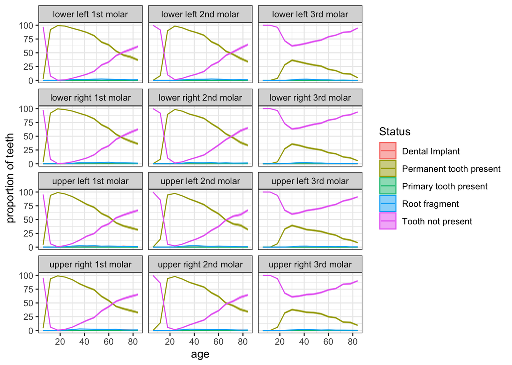

**Figure 1a.** *Tooth status as a function of age for molars.* Lines represents a linear interpolation of 6-year age buckets with the shaded areas providing (pointwise) 95% confidence intervals.

```r
cap_template = paste(
  "**Figure %s.** *Tooth status as a function of age for %s.*",
  "Lines represents a linear interpolation of 6-year age buckets with the",
  "shaded areas providing (pointwise) 95%% confidence intervals."
)
cap1a = sprintf(cap_template, "1a", "molars")
q3_clean %>%
  filter(grepl('molar', tooth_name)) %>%
  ggplot(aes(x = age, y = p, group = Status, color = Status) )  +
  geom_ribbon(
    aes(ymin = lwr, ymax = upr, fill = Status, color = NULL),
    alpha = 0.5
  ) +
  geom_line() +
  facet_wrap(~tooth_name, nrow = 4) +
  theme_bw() +
  ylab('proportion of teeth')
```

#### Cuspids

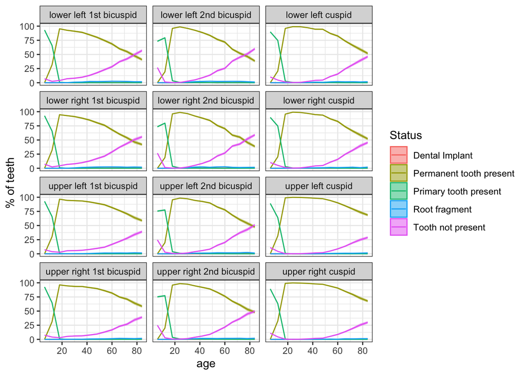

**Figure 1b.** *Tooth status as a function of age for cuspids and bicuspids.* Lines represents a linear interpolation of 6-year age buckets with the shaded areas providing (pointwise) 95% confidence intervals.

```r
cap1b = sprintf(cap_template, "1b", "cuspids and bicuspids")
q3_clean %>%
  filter(grepl('cuspid', tooth_name)) %>%
  ggplot(aes(x = age, y = p, group = Status, color = Status) )  +
  geom_ribbon(
    aes(ymin = lwr, ymax = upr, fill = Status, color = NULL),
    alpha = 0.5
  ) +
  geom_line() +
  facet_wrap(~tooth_name, nrow = 4) +
  theme_bw() +
  ylab('% of teeth')
```

#### Incisors

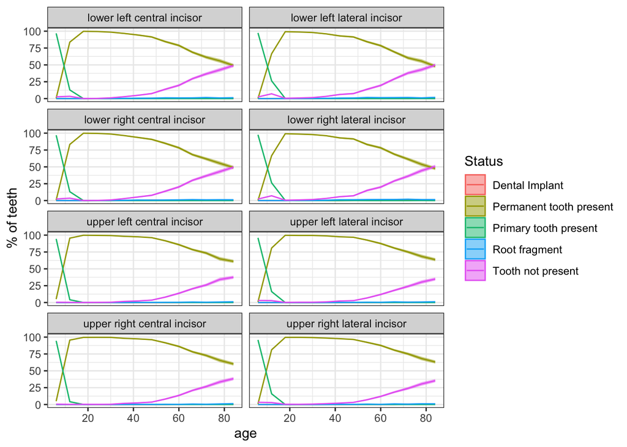

**Figure 1c.** *Tooth status as a function of age for incisors.* Lines represents a linear interpolation of 6-year age buckets with the shaded areas providing (pointwise) 95% confidence intervals.

```r
cap1c = sprintf(cap_template, "1c", "incisors")
q3_clean %>%
  filter(grepl('incisor', tooth_name)) %>%
  ggplot(aes(x = age, y = p, group = Status, color = Status) )  +
  geom_ribbon(
    aes(ymin = lwr, ymax = upr, fill = Status, color = NULL),
    alpha = 0.5
  ) +
  geom_line() +
  facet_wrap(~tooth_name, nrow = 4) +
  theme_bw() +
  ylab('% of teeth')
```